# Applied Machine Learning Using mlr3

Evaluation and Benchmarking

Author

Paul Smith

Published

March 21, 2025

# Introduction and prerequisites

The `{mlr3}` package uses the R6 class system alongside `data.table` to store and operate on tabular data.

For a brief introduction to the R6 class system, see [Section 1.5.1](https://mlr3book.mlr-org.com/chapters/chapter1/introduction_and_overview.html#sec-r6) of the mlr3 book, or the package [vignette](https://r6.r-lib.org/articles/Introduction.html).

For information on the `data.table` format, see the package [vignette](https://cran.r-project.org/web/packages/data.table/vignettes/datatable-intro.html).

This article follows the tutorial given in the *Applied Machine Learning Using mlr3 in R* [online notes](https://mlr3book.mlr-org.com/chapters/chapter3/evaluation_and_benchmarking.html) (Casalicchio and Burk 2024).

Casalicchio, Giuseppe, and Lukas Burk. 2024. “Evaluation and Benchmarking.” In *Applied Machine Learning Using mlr3 in R*, edited by Bernd Bischl, Raphael Sonabend, Lars Kotthoff, and Michel Lang. CRC Press. https://mlr3book.mlr-org.com/evaluation_and_benchmarking.html.

```r
library(mlr3)
library(mlr3viz)
library(mlr3learners)
library(mlr3data)
library(ggplot2)
library(patchwork)
library(data.table)
options(datatable.print.nrows = 20)
library(palmerpenguins)
```

## Structure

This article is structured as follows:

- Model building and validation using the data-splitting technique is discussed in Section 2.
- Resampling techniques are discussed in Section 3.
- Section 4 shows ways to compared models.
- Section 5 gives specific performance measures for binary classification.

A reference for more in-depth detail of measures and performance estimation is Japkowicz and Shah (2011).

Japkowicz, Nathalie, and Mohak Shah. 2011. *Evaluating Learning Algorithms: A Classification Perspective*. Cambridge University Press.

# Data-splitting and Scoring

This is a bad method (see my posts – [one](https://pws3141.github.io/blog/posts/06-stepwise_datasplitting/) and [two](https://pws3141.github.io/blog/posts/07-stepwise_datasplitting_simulation/) – for more information). Anyway, let’s do it.

```r
# the task is already loading in {mlr3}
#tsk_penguins = tsk("penguins")
# but, let's do it from scratch instead
data("penguins", package = "palmerpenguins")
set.seed(1)

penguins_dt <- as.data.table(penguins)
tsk_penguins <- as_task_classif(penguins_dt, target = "species", id = "penguins")
tsk_penguins
```

```
<TaskClassif:penguins> (344 x 8)
* Target: species
* Properties: multiclass
* Features (7):
  - int (3): body_mass_g, flipper_length_mm, year
  - dbl (2): bill_depth_mm, bill_length_mm
  - fct (2): island, sex
```

```r
splits = partition(tsk_penguins, ratio = 0.67)
lrn_rpart = lrn("classif.rpart")
lrn_rpart$train(tsk_penguins, splits$train)
prediction = lrn_rpart$predict(tsk_penguins, splits$test)
prediction$score(msr("classif.acc"))
```

```
classif.acc
  0.9385965
```

[figure not shown]

# Resampling Methods

[figure not shown]

A general abstraction of the performance estimation process. The available data is (repeatedly) split into training data and test data (data splitting / resampling process). The learner is trained on each training dataset and produces intermediate models (learning process). Each intermediate model makes predictions based on the features in the test data. The performance measure compares these predictions with the ground truth from the test data and computes a performance value for each test dataset. All performance values are aggregated into a scalar value to estimate the generalization performance (evaluation process).

This section focusses on Cross-Validation. In the tutorial, the authors state that:

> Bootstrapping has become less common, as having repeated observations in training data can lead to problems in some machine learning setups, especially when combined with model selection methods and nested resampling (as duplicated observations can then end up simultaneously in training and test sets in nested schemes).

I’m not sure this is true, and I don’t think Frank Harrell would agree with this statement, for example in his comment on the [datamethods](https://discourse.datamethods.org/t/bootstrap-vs-cross-validation-for-model-performance/2779) website.

For an explanation of using bootstrap to assess internal validation of a model, see the [stackexchange](https://stats.stackexchange.com/questions/466851/combining-bootstrap-and-cross-validation) post. For more detail, refer to Steyerberg (2019).

Steyerberg, Ewout W. 2019. “Statistical Models for Prediction.” In *Clinical Prediction Models: A Practical Approach to Development, Validation, and Updating*, 59–93. Cham: Springer International Publishing. https://doi.org/10.1007/978-3-030-16399-0_4.

[figure not shown]

Illustration of three-fold cross-validation

## Constructing a resampling strategy

Resampling strategies are stored in the `mlr_resamplings` dictionary.

```r
as.data.table(mlr_resamplings)
```

```
Key: <key>
           key                         label        params iters
        <char>                        <char>        <list> <int>
1:   bootstrap                     Bootstrap ratio,repeats    30
2:      custom                 Custom Splits                  NA
3:   custom_cv Custom Split Cross-Validation                  NA
4:          cv              Cross-Validation         folds    10
5:     holdout                       Holdout         ratio     1
6:    insample           Insample Resampling                   1
7:         loo                 Leave-One-Out                  NA
8: repeated_cv     Repeated Cross-Validation folds,repeats   100
9: subsampling                   Subsampling ratio,repeats    30
```

The `rsmp()` function is used to construct a `Resampling` object. For example, to create a holdout strategy with a 4/5 split,

```r
rsmp("holdout", ratio = 0.8)
```

```
<ResamplingHoldout>: Holdout
* Iterations: 1
* Instantiated: FALSE
* Parameters: ratio=0.8
```

Or other strategies:

```r
# three-fold CV
cv3 = rsmp("cv", folds = 3)
# Subsampling with 3 repeats and 9/10 ratio
ss390 = rsmp("subsampling", repeats = 3, ratio = 0.9)
# 2-repeats 5-fold CV
rcv25 = rsmp("repeated_cv", repeats = 2, folds = 5)
```

The `Resampling` object created gives a definition for how the data splitting process will be performed on a task. It is possible to manually instantiate a resampling strategy using `$instantiate()`:

```r
cv3$instantiate(tsk_penguins)
# first 10 observations in the second training set
cv3$train_set(2)[1:10]
```

```
 [1]  2  6  7 10 11 12 14 17 19 21
```

```r
# first 10 observations in the third test set
cv3$test_set(3)[1:10]
```

```
 [1]  1  4  5  8 13 16 18 29 33 34
```

Note that `$instantiate()` is rarely required, as we can use the `resample()` method to do it all.

## Resampling experiments

The `resample()` function requires a `Task`, `Learner` and `Resampling` objects. It stores the result in an `ResampleResult` object.

```r
rr <- resample(tsk_penguins, lrn_rpart, cv3)
```

```
INFO  [11:52:59.694] [mlr3] Applying learner 'classif.rpart' on task 'penguins' (iter 1/3)
INFO  [11:52:59.719] [mlr3] Applying learner 'classif.rpart' on task 'penguins' (iter 2/3)
INFO  [11:52:59.727] [mlr3] Applying learner 'classif.rpart' on task 'penguins' (iter 3/3)
```

```r
rr
```

```
<ResampleResult> with 3 resampling iterations
  task_id    learner_id resampling_id iteration     prediction_test warnings
 penguins classif.rpart            cv         1 <PredictionClassif>        0
 penguins classif.rpart            cv         2 <PredictionClassif>        0
 penguins classif.rpart            cv         3 <PredictionClassif>        0
 errors
      0
      0
      0
```

We can calculate the score for each iteration using `$score()`.[^1]

<sup>1</sup> By default, `score()` evaluates the performance in the test sets in each iteration.

```r
acc <- rr$score(msr("classif.ce"))
acc
```

```
    task_id    learner_id resampling_id iteration classif.ce
     <char>        <char>        <char>     <int>      <num>
1: penguins classif.rpart            cv         1 0.10434783
2: penguins classif.rpart            cv         2 0.05217391
3: penguins classif.rpart            cv         3 0.03508772
Hidden columns: task, learner, resampling, prediction_test
```

The score can also be aggregated over the iterations. By default, the `classif.ce` score uses *macro* average, where the score is calculated for each iteration, and then averaged. The *micro* average can be computed, where the predictions are pooled across iterations into one `Prediction` object, and then a single score calculated.

```r
# the default aggregation method can be found in the $average field
msr("classif.ce")$average
```

```
[1] "macro"
```

```r
# macro
rr$aggregate(msr("classif.ce"))
```

```
classif.ce
0.06386982
```

```r
# micro
rr$aggregate(msr("classif.ce", average = "micro"))
```

```
classif.ce
0.06395349
```

[figure not shown]

An example of the difference between `$score()` and `$aggregate()`

The results can be visualised using the `autoplot.ResampleResult()` function.

```r
rr = resample(tsk_penguins, lrn_rpart, rsmp("cv", folds = 10))
```

```
INFO  [11:52:59.778] [mlr3] Applying learner 'classif.rpart' on task 'penguins' (iter 1/10)
INFO  [11:52:59.783] [mlr3] Applying learner 'classif.rpart' on task 'penguins' (iter 2/10)
INFO  [11:52:59.788] [mlr3] Applying learner 'classif.rpart' on task 'penguins' (iter 3/10)
INFO  [11:52:59.793] [mlr3] Applying learner 'classif.rpart' on task 'penguins' (iter 4/10)
INFO  [11:52:59.798] [mlr3] Applying learner 'classif.rpart' on task 'penguins' (iter 5/10)
INFO  [11:52:59.803] [mlr3] Applying learner 'classif.rpart' on task 'penguins' (iter 6/10)
INFO  [11:52:59.807] [mlr3] Applying learner 'classif.rpart' on task 'penguins' (iter 7/10)
INFO  [11:52:59.831] [mlr3] Applying learner 'classif.rpart' on task 'penguins' (iter 8/10)
INFO  [11:52:59.836] [mlr3] Applying learner 'classif.rpart' on task 'penguins' (iter 9/10)
INFO  [11:52:59.841] [mlr3] Applying learner 'classif.rpart' on task 'penguins' (iter 10/10)
```

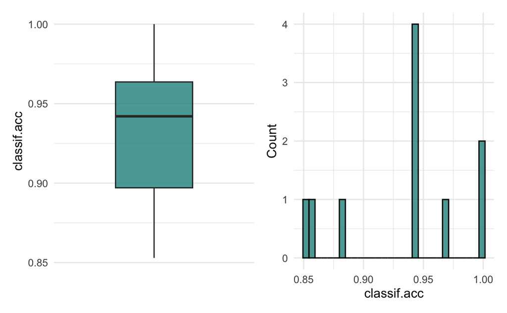

Boxplot (left) and histogram (right) of accuracy scores for 10-fold CV

```r
gg1 <- autoplot(rr, measure = msr("classif.acc"), type = "boxplot")
gg2 <- autoplot(rr, measure = msr("classif.acc"), type = "histogram")
gg1 + gg2
```

## ResampleResult objects

In general, the intermediate models produced for each iterations are not stored in the `ResampleResult` object, to save memory. However, we can configure the `resample()` function to keep these models.

```r
rr <- resample(tsk_penguins, lrn_rpart, cv3, store_models = TRUE)
```

**Model 1**

```r
rr$learners[[1]]
```

```
<LearnerClassifRpart:classif.rpart>: Classification Tree
* Model: rpart
* Parameters: xval=0
* Packages: mlr3, rpart
* Predict Types:  [response], prob
* Feature Types: logical, integer, numeric, factor, ordered
* Properties: importance, missings, multiclass, selected_features,
  twoclass, weights
```

```r
rr$learners[[1]]$model
```

```
n= 229

node), split, n, loss, yval, (yprob)
      * denotes terminal node

1) root 229 123 Adelie (0.462882096 0.179039301 0.358078603)
  2) flipper_length_mm< 207.5 145  40 Adelie (0.724137931 0.268965517 0.006896552)
    4) bill_length_mm< 43.05 104   1 Adelie (0.990384615 0.009615385 0.000000000) *
    5) bill_length_mm>=43.05 41   3 Chinstrap (0.048780488 0.926829268 0.024390244) *
  3) flipper_length_mm>=207.5 84   3 Gentoo (0.011904762 0.023809524 0.964285714) *
```

**Model 2**

```r
rr$learners[[2]]
```

```
<LearnerClassifRpart:classif.rpart>: Classification Tree
* Model: rpart
* Parameters: xval=0
* Packages: mlr3, rpart
* Predict Types:  [response], prob
* Feature Types: logical, integer, numeric, factor, ordered
* Properties: importance, missings, multiclass, selected_features,
  twoclass, weights
```

```r
rr$learners[[2]]$model
```

```
n= 229

node), split, n, loss, yval, (yprob)
      * denotes terminal node

1) root 229 128 Adelie (0.441048035 0.218340611 0.340611354)
  2) flipper_length_mm< 206 148  48 Adelie (0.675675676 0.317567568 0.006756757)
    4) bill_length_mm< 43.35 101   4 Adelie (0.960396040 0.039603960 0.000000000) *
    5) bill_length_mm>=43.35 47   4 Chinstrap (0.063829787 0.914893617 0.021276596) *
  3) flipper_length_mm>=206 81   4 Gentoo (0.012345679 0.037037037 0.950617284) *
```

**Model 3**

```r
rr$learners[[3]]
```

```
<LearnerClassifRpart:classif.rpart>: Classification Tree
* Model: rpart
* Parameters: xval=0
* Packages: mlr3, rpart
* Predict Types:  [response], prob
* Feature Types: logical, integer, numeric, factor, ordered
* Properties: importance, missings, multiclass, selected_features,
  twoclass, weights
```

```r
rr$learners[[3]]$model
```

```
n= 230

node), split, n, loss, yval, (yprob)
      * denotes terminal node

1) root 230 133 Adelie (0.42173913 0.19565217 0.38260870)
  2) flipper_length_mm< 206.5 136  41 Adelie (0.69852941 0.30147059 0.00000000)
    4) bill_length_mm< 43.35 96   4 Adelie (0.95833333 0.04166667 0.00000000) *
    5) bill_length_mm>=43.35 40   3 Chinstrap (0.07500000 0.92500000 0.00000000) *
  3) flipper_length_mm>=206.5 94   6 Gentoo (0.02127660 0.04255319 0.93617021)
    6) bill_depth_mm>=17.15 7   3 Chinstrap (0.28571429 0.57142857 0.14285714) *
    7) bill_depth_mm< 17.15 87   0 Gentoo (0.00000000 0.00000000 1.00000000) *
```

We can also use this to inspect the most important variables in each iteration to help us learn more about the models.

```r
# print 2nd and 3rd iteration
lapply(rr$learners, function(x) x$model$variable.importance)
```

```
[[1]]
   bill_length_mm flipper_length_mm     bill_depth_mm       body_mass_g
         85.43919          84.15311          63.88115          59.18401
           island
         46.03200

[[2]]
flipper_length_mm    bill_length_mm     bill_depth_mm       body_mass_g
         85.26061          76.48758          58.99729          57.18199
           island
         49.49225

[[3]]
flipper_length_mm    bill_length_mm     bill_depth_mm       body_mass_g
         85.05119          82.31704          75.02863          61.15834
           island
         48.21192
```

## Custom resampling

If custom resampling is required, then the `rsmp("custom")` function can be used. See [Section 3.2.4](https://mlr3book.mlr-org.com/chapters/chapter3/evaluation_and_benchmarking.html#sec-resamp-custom) of the {mlr3} tutorial to learn more.

## Stratification and grouping

It is possible to group or stratify observations. Grouped sampling can be used to ensure that all observations of the same group (*e.g.* country) belong to either the training or test set, to prevent leaking information. Stratified sampling ensures that one or more discrete features within the training of test sets will have a similar distribution an in the original task containing all observations.

For information, see [Section 3.2.5](https://mlr3book.mlr-org.com/chapters/chapter3/evaluation_and_benchmarking.html#sec-strat-group) of the {mlr3} tutorial.

# Benchmarking

**Benchmarking**

the comparison of different learners on one or more tasks.

## `benchmark()`

The `benchmark()` function runs `resample()` on each task and learner separately and collates the results.

To use `benchmark()` we first need to call `benchmark_grid()`, which constructs an exhaustive design to describe all combinations of the learners, tasks and resamplings to be used in a benchmark experiment.[^2]

<sup>2</sup> By default, `benchmark_grid()` instantiates the resamplings on the tasks, which means that concrete train-test splits are generated. Since this process is stochastic, it is necessary to set a seed before calling `benchmark_grid()` to ensure reproducibility of the data splits.

```r
tasks = tsks(c("german_credit", "sonar"))
# 'classif.ranger' is a random classification forest
learners = lrns(c("classif.rpart", "classif.ranger",
  "classif.featureless"), predict_type = "prob")
rsmp_cv5 = rsmp("cv", folds = 5)

design = benchmark_grid(tasks, learners, rsmp_cv5)
design
```

```
            task             learner resampling
          <char>              <char>     <char>
1: german_credit       classif.rpart         cv
2: german_credit      classif.ranger         cv
3: german_credit classif.featureless         cv
4:         sonar       classif.rpart         cv
5:         sonar      classif.ranger         cv
6:         sonar classif.featureless         cv
```

Then we can run an experiement on the benchmark design.

```r
bmr = benchmark(design)
bmr
```

```
<BenchmarkResult> of 30 rows with 6 resampling runs
 nr       task_id          learner_id resampling_id iters warnings errors
  1 german_credit       classif.rpart            cv     5        0      0
  2 german_credit      classif.ranger            cv     5        0      0
  3 german_credit classif.featureless            cv     5        0      0
  4         sonar       classif.rpart            cv     5        0      0
  5         sonar      classif.ranger            cv     5        0      0
  6         sonar classif.featureless            cv     5        0      0
```

As `benchmark()` is an extension of `resample()`, we can obtain the score, and aggregate in the same way.

```r
bmr$score()[, .(iteration, task_id, learner_id, classif.ce)]
```

```
    iteration       task_id          learner_id classif.ce
        <int>        <char>              <char>      <num>
 1:         1 german_credit       classif.rpart  0.2450000
 2:         2 german_credit       classif.rpart  0.2700000
 3:         3 german_credit       classif.rpart  0.2800000
 4:         4 german_credit       classif.rpart  0.2850000
 5:         5 german_credit       classif.rpart  0.2700000
---
26:         1         sonar classif.featureless  0.5952381
27:         2         sonar classif.featureless  0.4285714
28:         3         sonar classif.featureless  0.4523810
29:         4         sonar classif.featureless  0.6829268
30:         5         sonar classif.featureless  0.5365854
```

```r
bmr$aggregate()[, .(task_id, learner_id, classif.ce)]
```

```
         task_id          learner_id classif.ce
          <char>              <char>      <num>
1: german_credit       classif.rpart  0.2700000
2: german_credit      classif.ranger  0.2310000
3: german_credit classif.featureless  0.3000000
4:         sonar       classif.rpart  0.2837398
5:         sonar      classif.ranger  0.2017422
6:         sonar classif.featureless  0.5391405
```

Here, we can possibly conclude that the random forest is the best of all three models on each task, although some analysis will have to be done to assert this confidently.[^3]

<sup>3</sup> How to do this analysis comes much later in the {mlr3} [tutorial](https://mlr3book.mlr-org.com/chapters/chapter11/large-scale_benchmarking.html#sec-benchmark-analysis)

### BenchmarkResult objects

A `BenchmarkResult` object is a collection of multiple `ResampleResult` objects. It stores and organizes the results of benchmarking multiple machine learning models (`Learners`) on one or more tasks. It is created when you run a benchmark experiment using `benchmark()`.

```r
bmrdt = as.data.table(bmr)
bmrdt[, .(task, learner, resampling, iteration)]
```

```
                           task                                         learner
                         <list>                                          <list>
 1: <TaskClassif:german_credit>             <LearnerClassifRpart:classif.rpart>
 2: <TaskClassif:german_credit>             <LearnerClassifRpart:classif.rpart>
 3: <TaskClassif:german_credit>             <LearnerClassifRpart:classif.rpart>
 4: <TaskClassif:german_credit>             <LearnerClassifRpart:classif.rpart>
 5: <TaskClassif:german_credit>             <LearnerClassifRpart:classif.rpart>
---
26:         <TaskClassif:sonar> <LearnerClassifFeatureless:classif.featureless>
27:         <TaskClassif:sonar> <LearnerClassifFeatureless:classif.featureless>
28:         <TaskClassif:sonar> <LearnerClassifFeatureless:classif.featureless>
29:         <TaskClassif:sonar> <LearnerClassifFeatureless:classif.featureless>
30:         <TaskClassif:sonar> <LearnerClassifFeatureless:classif.featureless>
        resampling iteration
            <list>     <int>
 1: <ResamplingCV>         1
 2: <ResamplingCV>         2
 3: <ResamplingCV>         3
 4: <ResamplingCV>         4
 5: <ResamplingCV>         5
---
26: <ResamplingCV>         1
27: <ResamplingCV>         2
28: <ResamplingCV>         3
29: <ResamplingCV>         4
30: <ResamplingCV>         5
```

The `ResampleResults` can be extracted via the `$resample_result(i)`.

```r
rr1 = bmr$resample_result(1)
rr1
```

```
<ResampleResult> with 5 resampling iterations
       task_id    learner_id resampling_id iteration     prediction_test
 german_credit classif.rpart            cv         1 <PredictionClassif>
 german_credit classif.rpart            cv         2 <PredictionClassif>
 german_credit classif.rpart            cv         3 <PredictionClassif>
 german_credit classif.rpart            cv         4 <PredictionClassif>
 german_credit classif.rpart            cv         5 <PredictionClassif>
 warnings errors
        0      0
        0      0
        0      0
        0      0
        0      0
```

```r
rr2 = bmr$resample_result(2)
```

And, `as_benchmark_result()` can be used to convert objects from `ResampleResult` to `BenchmarkResult`.

```r
bmr1 = as_benchmark_result(rr1)
bmr2 = as_benchmark_result(rr2)

c(bmr1, bmr2)
```

```
<BenchmarkResult> of 10 rows with 2 resampling runs
 nr       task_id     learner_id resampling_id iters warnings errors
  1 german_credit  classif.rpart            cv     5        0      0
  2 german_credit classif.ranger            cv     5        0      0
```

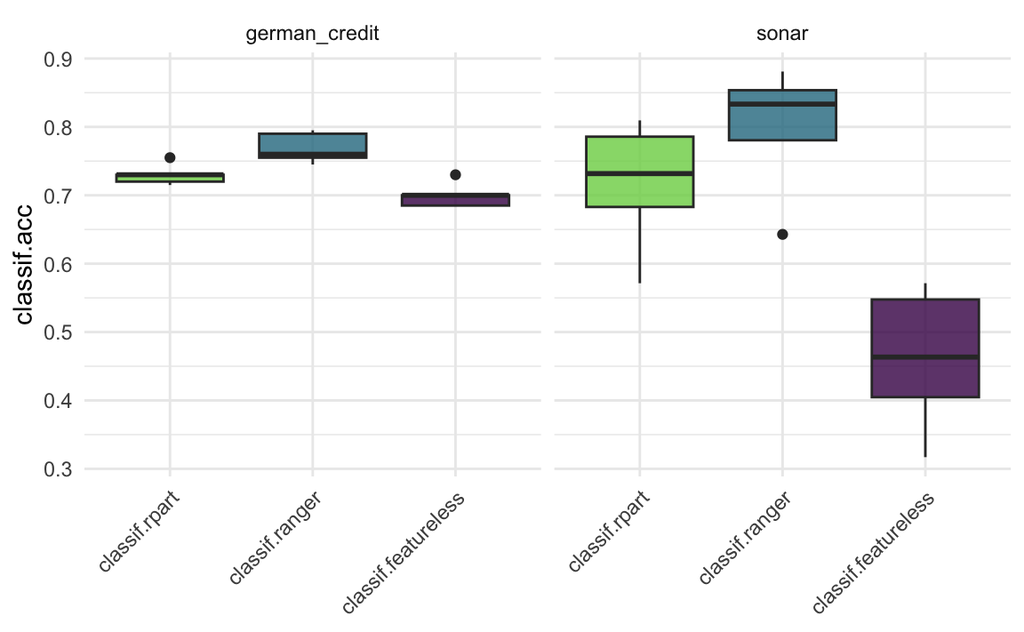

```r
autoplot(bmr, measure = msr("classif.acc"))
```

# Evaluating Binary Classifiers

Here, we look at using the confusion matrix (Section 5.1), and ROC analysis (Section 5.2) to evaluate binary classifiers.

## Confusion matrix

Confusion matrices give:

- True positives (TPs): Positive instances that are correctly classified as positive.
- True negatives (TNs): Negative instances that are correctly classified as negative.
- False positives (FPs): Negative instances that are incorrectly classified as positive.
- False negatives (FNs): Positive instances that are incorrectly classified as negative.

```r
tsk_german = tsk("german_credit")
lrn_ranger = lrn("classif.ranger", predict_type = "prob")
splits = partition(tsk_german, ratio = 0.8)

lrn_ranger$train(tsk_german, splits$train)
prediction = lrn_ranger$predict(tsk_german, splits$test)
prediction$score(msr("classif.acc"))
```

```
classif.acc
      0.785
```

```r
prediction$confusion
```

Listing 1: The confusion matrix for the random forest learner on the ‘german_credit’ data.

```
        truth
response good bad
    good  129  39
    bad     4  28
```

Here, although the accuracy score might be OK, it is clear that the predictions are not very good at correctly predicting the ‘bad’ outcomes.

Normalised measures can be used to account for class imbalances.

- True Positive Rate (TPR), Sensitivity or Recall: How many of the true positives did we predict as positive?
- True Negative Rate (TNR) or Specificity: How many of the true negatives did we predict as negative?
- False Positive Rate (FPR), or $1 -$ Specificity: How many of the true negatives did we predict as positive?
- Positive Predictive Value (PPV) or Precision: If we predict positive how likely is it a true positive?
- Negative Predictive Value (NPV): If we predict negative how likely is it a true negative?
- Accuracy (ACC): The proportion of correctly classified instances out of the total number of instances.
- F1-score: The harmonic mean of precision and recall, which balances the trade-off between precision and recall. It is calculated as

$$2 \times \frac{\text{Precision} \times \text{Recall}}{{Precision} + \text{Recall}}$$

[figure not shown]

Binary confusion matrix of ground truth class vs. predicted class

These measures can be computed using the `{mlr3measures}` package (Lang, Becker, and Koers 2024).

```r
mlr3measures::confusion_matrix(truth = prediction$truth,
  response = prediction$response, positive = tsk_german$positive)
```

```
        truth
response good bad
    good  129  39
    bad     4  28
acc :  0.7850; ce  :  0.2150; dor :  23.1538; f1  :  0.8571
fdr :  0.2321; fnr :  0.0301; fomr:  0.1250; fpr :  0.5821
mcc :  0.4993; npv :  0.8750; ppv :  0.7679; tnr :  0.4179
tpr :  0.9699
```

The false positive rate is quite high, as expected from looking at the confusion matrix obtained from `prediction$confusion` in Listing 1. There is generally a trade off between FPR and TPR. Using `predict_type = "prob"` to obtain predicted probabilities of being in the positive class, we can change the threshold to cut off when we assign observations to the positive / negative class. Increasing this threshold for identifying positive cases will lead to a higher number of negative predictions – therefore a lower (better) FPR but a lower (worse) TPR (and vice-versa).

## ROC analysis

ROC (Receiver Operating Characteristic) analysis is widely used to evaluate binary classifiers by visualizing the trade-off between the TPR and the FPR.

We can use the previous `Prediction` object to compute all possible TPR and FPR combinations by thresholding the predicted probabilities across all possible thresholds This is what is done in `mlr3viz::autoplot.PredictionClassif` when `type = "roc"` is chosen. FPR is on the $x$-axis, and TPR on the $y$-axis.

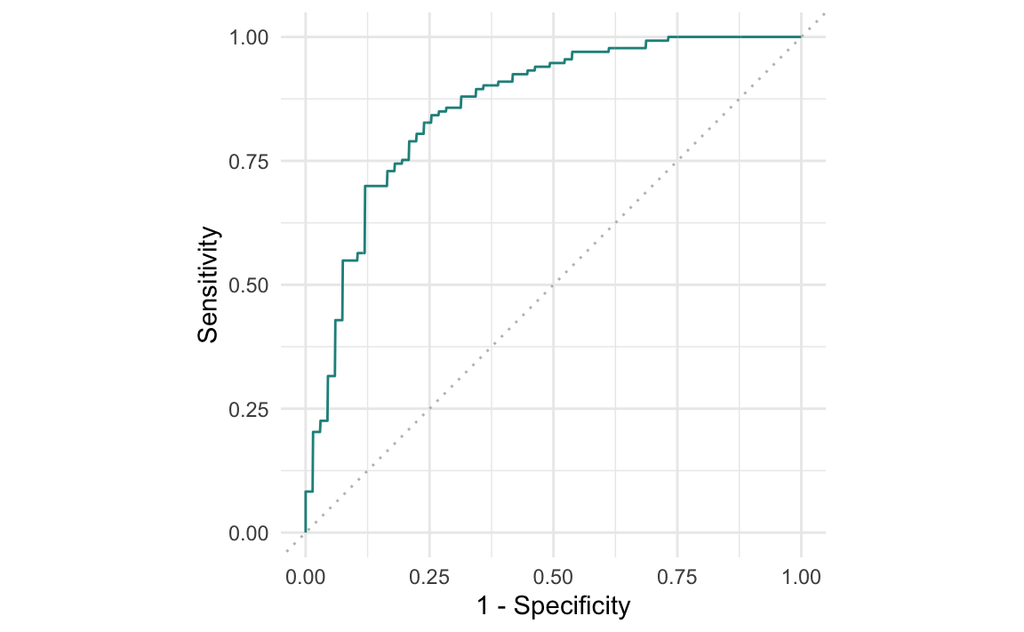

```r
autoplot(prediction, type = "roc")
```

The area under the curve (AUC) of a ROC can be interprested as the probability that a randomly chosen positive instance has a higher predicted probability of belonging to the positive class than a randomly chosen negative instance.

```r
prediction$score(msr("classif.auc"))
```

```
classif.auc
  0.8592751
```

The precision-recall curve (PRC) can also be plotted. This visualises the precision (PPV) vs. recall (TPR). The main difference between PRC and ROC is that true-negatives are ignored in the former, which can be useful in imbalanced populations where the positive class is rare.

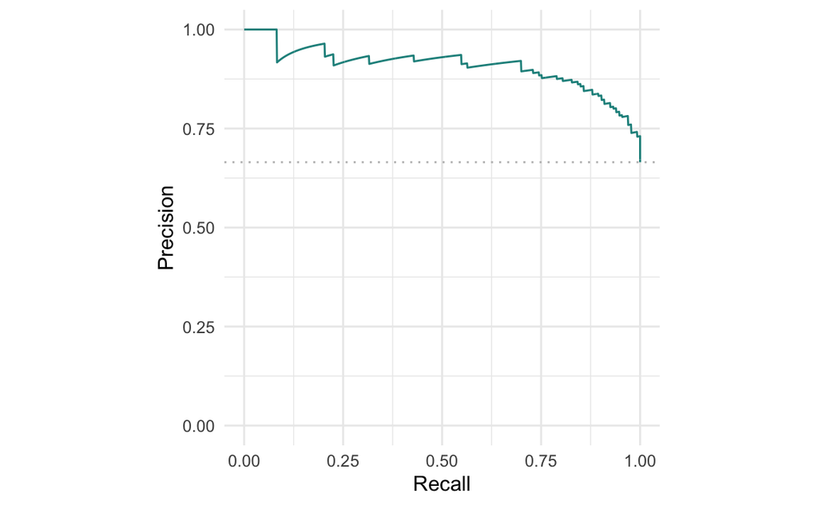

```r
autoplot(prediction, type = "prc")
```

We can also see how the performance metrics change with respect to the threshold. Here, we plot the FPR and the accuracy.

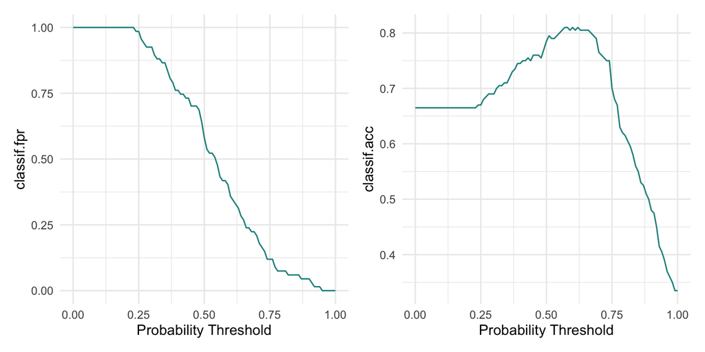

```r
gg1 <- autoplot(prediction, type = "threshold", measure = msr("classif.fpr"))
gg2 <- autoplot(prediction, type = "threshold", measure = msr("classif.acc"))

gg1 + gg2
```

We can look at the variability for each resampling iteration via the `ResampleResult` object.

```r
rr = resample(
  task = tsk("german_credit"),
  learner = lrn("classif.ranger", predict_type = "prob"),
  resampling = rsmp("cv", folds = 5)
)
```

```
INFO  [11:53:02.910] [mlr3] Applying learner 'classif.ranger' on task 'german_credit' (iter 1/5)
INFO  [11:53:03.045] [mlr3] Applying learner 'classif.ranger' on task 'german_credit' (iter 2/5)
INFO  [11:53:03.173] [mlr3] Applying learner 'classif.ranger' on task 'german_credit' (iter 3/5)
INFO  [11:53:03.299] [mlr3] Applying learner 'classif.ranger' on task 'german_credit' (iter 4/5)
INFO  [11:53:03.430] [mlr3] Applying learner 'classif.ranger' on task 'german_credit' (iter 5/5)
```

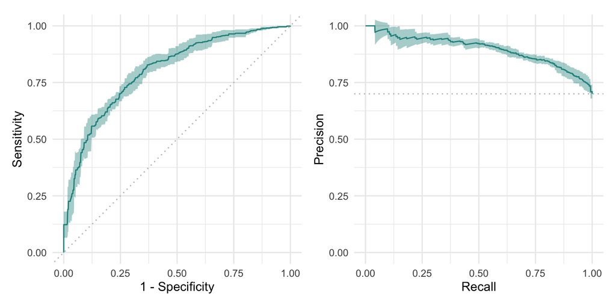

```r
gg1 <- autoplot(rr, type = "roc")
gg2 <- autoplot(rr, type = "prc")

gg1 + gg2
```

And, we can use the `BenchmarkResult` to compare multiple learners on the same `Task`.

```r
design = benchmark_grid(
  tasks = tsk("german_credit"),
  learners = lrns(c("classif.rpart", "classif.ranger"),
    predict_type = "prob"),
  resamplings = rsmp("cv", folds = 5)
)
bmr = benchmark(design)
```

```
INFO  [11:53:03.845] [mlr3] Running benchmark with 10 resampling iterations
INFO  [11:53:03.847] [mlr3] Applying learner 'classif.rpart' on task 'german_credit' (iter 1/5)
INFO  [11:53:03.855] [mlr3] Applying learner 'classif.rpart' on task 'german_credit' (iter 2/5)
INFO  [11:53:03.863] [mlr3] Applying learner 'classif.rpart' on task 'german_credit' (iter 3/5)
INFO  [11:53:03.872] [mlr3] Applying learner 'classif.rpart' on task 'german_credit' (iter 4/5)
INFO  [11:53:03.880] [mlr3] Applying learner 'classif.rpart' on task 'german_credit' (iter 5/5)
INFO  [11:53:03.889] [mlr3] Applying learner 'classif.ranger' on task 'german_credit' (iter 1/5)
INFO  [11:53:04.014] [mlr3] Applying learner 'classif.ranger' on task 'german_credit' (iter 2/5)
INFO  [11:53:04.147] [mlr3] Applying learner 'classif.ranger' on task 'german_credit' (iter 3/5)
INFO  [11:53:04.274] [mlr3] Applying learner 'classif.ranger' on task 'german_credit' (iter 4/5)
INFO  [11:53:04.403] [mlr3] Applying learner 'classif.ranger' on task 'german_credit' (iter 5/5)
INFO  [11:53:04.530] [mlr3] Finished benchmark
```

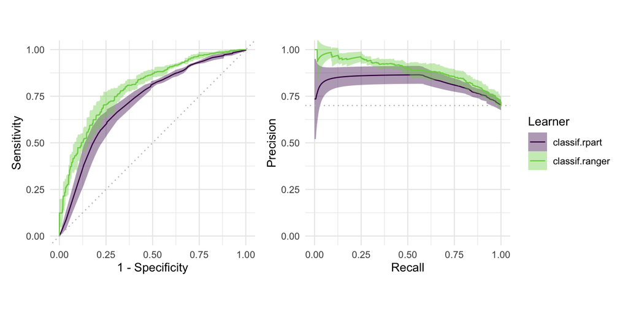

```r
autoplot(bmr, type = "roc") + autoplot(bmr, type = "prc") +
  plot_layout(guides = "collect")
```

I’m not sure why in the ROC plot, the $y$-axis is labeled as ‘Sensitivity’, whilst in the PRC, the $x$-axis is labeled ‘Recall’. Maybe it’s due to historical reasons?

# Conclusion

Here, we learned how to estimate the generalisation performance of a model via resampling (holdout, CV, bootstrap), and how to automate the comparison of multiple learners in benchmark experiments.

| Class | Constructor/Function | Fields/Methods |
| --- | --- | --- |
| `PredictionClassif` | `classif_lrn$predict()` | `confusion_matrix()`; `autoplot(some_prediction_classif, type = "roc")` |
| - | `partition()` | - |
| `Resampling` | `rsmp()` | `$instantiate()` |
| `ResampleResult` | `resample()` | `$score()`; `$aggregate()`; `$predictions()`; `as_benchmark_result()`; `autoplot(some_resample_result, type = "roc")` |
| - | `benchmark_grid()` | - |
| `BenchmarkResult` | `benchmark()` | `$aggregate()`; `$resample_result()`; `$score()`; `autoplot(some_benchmark_result, type = "roc")` |

# Exercises

1. Apply a repeated cross-validation resampling strategy on `tsk("mtcars")` and evaluate the performance of `lrn("regr.rpart")`.
   - Use five repeats of three folds each.
   - Calculate the MSE for each iteration and visualize the result.
   - Finally, calculate the aggregated performance score.
2. Use `tsk("spam")` and five-fold CV to benchmark `lrn("classif.ranger")`, `lrn("classif.log_reg")`, and `lrn("classif.xgboost", nrounds = 100)` with respect to AUC.
   - Which learner appears to perform best?
   - How confident are you in your conclusion?
   - Think about the stability of results and investigate this by re-running the experiment with different seeds.
   - What can be done to improve this?
3. A colleague reports a 93.1% classification accuracy using `lrn("classif.rpart")` on `tsk("penguins_simple")`.
   - You want to reproduce their results and ask them about their resampling strategy.
   - They said they used a custom three-fold CV with folds assigned as `factor(task$row_ids %% 3)`.
   - See if you can reproduce their results.
4. (*) Program your own ROC plotting function **without** using `mlr3`’s `autoplot()` function.
   - The signature of your function should be `my_roc_plot(task, learner, train_indices, test_indices)`.
   - Your function should use the `$set_threshold()` method of `Prediction`, as well as `mlr3measures`.

First, let’s suppress all messaging unless it’s a warning:[^4]

<sup>4</sup> See [Section 10.3](https://mlr3book.mlr-org.com/chapters/chapter10/advanced_technical_aspects_of_mlr3.html#sec-logging) of the tutorial for more information about mlr3 logging output)

```r
lgr::get_logger("mlr3")$set_threshold("warn")
```

## Question 1

Apply a repeated cross-validation resampling strategy on `tsk("mtcars")` and evaluate the performance of `lrn("regr.rpart")`.

- Use five repeats of three folds each.
- Calculate the MSE for each iteration and visualize the result.
- Finally, calculate the aggregated performance score.

### Answer

First, I’ll load the `Task`, `Learner`, and create the `rsmp()` object.

```r
tsk_mtcars <- tsk("mtcars")
tsk_mtcars
```

```
<TaskRegr:mtcars> (32 x 11): Motor Trends
* Target: mpg
* Properties: -
* Features (10):
  - dbl (10): am, carb, cyl, disp, drat, gear, hp, qsec, vs, wt
```

```r
# load learner
lrn_rpart <- lrn("regr.rpart")
lrn_rpart
```

```
<LearnerRegrRpart:regr.rpart>: Regression Tree
* Model: -
* Parameters: xval=0
* Packages: mlr3, rpart
* Predict Types:  [response]
* Feature Types: logical, integer, numeric, factor, ordered
* Properties: importance, missings, selected_features, weights
```

```r
# load resampling method: 5 lots of three-fold CV
rcv53 = rsmp("repeated_cv", repeats = 5, folds = 3)
rcv53
```

```
<ResamplingRepeatedCV>: Repeated Cross-Validation
* Iterations: 15
* Instantiated: FALSE
* Parameters: folds=3, repeats=5
```

Now, I’ll use the `resample()` function to run the resampling strategy.

```r
rr <- resample(tsk_mtcars, lrn_rpart, rcv53)
rr
```

```
<ResampleResult> with 15 resampling iterations
 task_id learner_id resampling_id iteration  prediction_test warnings errors
  mtcars regr.rpart   repeated_cv         1 <PredictionRegr>        0      0
  mtcars regr.rpart   repeated_cv         2 <PredictionRegr>        0      0
  mtcars regr.rpart   repeated_cv         3 <PredictionRegr>        0      0
  mtcars regr.rpart   repeated_cv         4 <PredictionRegr>        0      0
  mtcars regr.rpart   repeated_cv         5 <PredictionRegr>        0      0
  mtcars regr.rpart   repeated_cv         6 <PredictionRegr>        0      0
  mtcars regr.rpart   repeated_cv         7 <PredictionRegr>        0      0
  mtcars regr.rpart   repeated_cv         8 <PredictionRegr>        0      0
  mtcars regr.rpart   repeated_cv         9 <PredictionRegr>        0      0
  mtcars regr.rpart   repeated_cv        10 <PredictionRegr>        0      0
  mtcars regr.rpart   repeated_cv        11 <PredictionRegr>        0      0
  mtcars regr.rpart   repeated_cv        12 <PredictionRegr>        0      0
  mtcars regr.rpart   repeated_cv        13 <PredictionRegr>        0      0
  mtcars regr.rpart   repeated_cv        14 <PredictionRegr>        0      0
  mtcars regr.rpart   repeated_cv        15 <PredictionRegr>        0      0
```

Calculating the MSE for each iteration requires running `$score()`.

```r
rr_mse <- rr$score(msr("regr.mse"))
rr_mse
```

```
    task_id learner_id resampling_id iteration regr.mse
     <char>     <char>        <char>     <int>    <num>
 1:  mtcars regr.rpart   repeated_cv         1 23.95000
 2:  mtcars regr.rpart   repeated_cv         2 14.86109
 3:  mtcars regr.rpart   repeated_cv         3 23.32183
 4:  mtcars regr.rpart   repeated_cv         4 17.18795
 5:  mtcars regr.rpart   repeated_cv         5 17.59202
 6:  mtcars regr.rpart   repeated_cv         6 22.44044
 7:  mtcars regr.rpart   repeated_cv         7 18.95526
 8:  mtcars regr.rpart   repeated_cv         8 14.08928
 9:  mtcars regr.rpart   repeated_cv         9 18.59022
10:  mtcars regr.rpart   repeated_cv        10 11.18868
11:  mtcars regr.rpart   repeated_cv        11 17.59309
12:  mtcars regr.rpart   repeated_cv        12 16.17089
13:  mtcars regr.rpart   repeated_cv        13 23.44108
14:  mtcars regr.rpart   repeated_cv        14 29.98823
15:  mtcars regr.rpart   repeated_cv        15 29.90887
Hidden columns: task, learner, resampling, prediction_test
```

Let’s plot this.

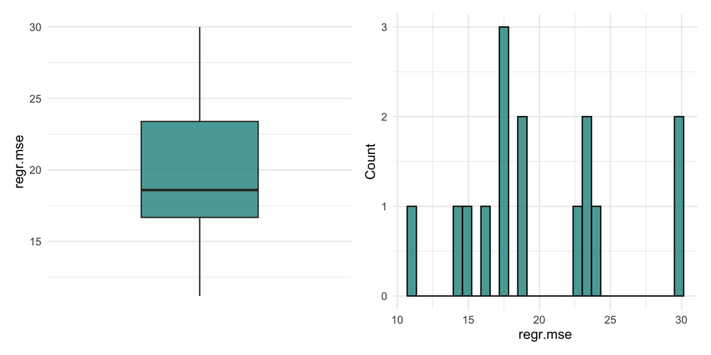

```r
autoplot(rr, measure = msr("regr.mse"), type = "boxplot") +
autoplot(rr, measure = msr("regr.mse"), type = "histogram")
```

Aggregating the MSE scores gives:

```r
rr$aggregate(msr("regr.mse"))
```

```
regr.mse
19.95193
```

## Question 2

Use `tsk("spam")` and five-fold CV to benchmark `lrn("classif.ranger")`, `lrn("classif.log_reg")`, and `lrn("classif.xgboost", nrounds = 100)` with respect to AUC.

- Which learner appears to perform best?
- How confident are you in your conclusion?
- Think about the stability of results and investigate this by re-running the experiment with different seeds.
- What can be done to improve this?

### Answer

Let’s load the task, learners and resampling method.

```r
tsk_spam <- tsk("spam")
tsk_spam
```

```
<TaskClassif:spam> (4601 x 58): HP Spam Detection
* Target: type
* Properties: twoclass
* Features (57):
  - dbl (57): address, addresses, all, business, capitalAve,
    capitalLong, capitalTotal, charDollar, charExclamation, charHash,
    charRoundbracket, charSemicolon, charSquarebracket, conference,
    credit, cs, data, direct, edu, email, font, free, george, hp, hpl,
    internet, lab, labs, mail, make, meeting, money, num000, num1999,
    num3d, num415, num650, num85, num857, order, original, our, over,
    parts, people, pm, project, re, receive, remove, report, table,
    technology, telnet, will, you, your
```

```r
# set up leaners
# first set up the 'lrns()' then modify the xgboost 'nrounds' argument
learners <- lrns(c("classif.ranger", "classif.log_reg", "classif.xgboost"),
                 predict_type = "prob")
# adjust 'nrounds' argument for xgboost
learners$classif.xgboost$param_set$values$nrounds <- 100
learners
```

```
$classif.ranger
<LearnerClassifRanger:classif.ranger>: Random Forest
* Model: -
* Parameters: num.threads=1
* Packages: mlr3, mlr3learners, ranger
* Predict Types:  response, [prob]
* Feature Types: logical, integer, numeric, character, factor, ordered
* Properties: hotstart_backward, importance, missings, multiclass,
  oob_error, twoclass, weights

$classif.log_reg
<LearnerClassifLogReg:classif.log_reg>: Logistic Regression
* Model: -
* Parameters: list()
* Packages: mlr3, mlr3learners, stats
* Predict Types:  response, [prob]
* Feature Types: logical, integer, numeric, character, factor, ordered
* Properties: twoclass, weights

$classif.xgboost
<LearnerClassifXgboost:classif.xgboost>: Extreme Gradient Boosting
* Model: -
* Parameters: nrounds=100, nthread=1, verbose=0
* Validate: NULL
* Packages: mlr3, mlr3learners, xgboost
* Predict Types:  response, [prob]
* Feature Types: logical, integer, numeric
* Properties: hotstart_forward, importance, internal_tuning, missings,
  multiclass, twoclass, validation, weights
```

```r
# set up resampling
cv5 <- rsmp("cv", folds = 5)
cv5
```

```
<ResamplingCV>: Cross-Validation
* Iterations: 5
* Instantiated: FALSE
* Parameters: folds=5
```

Now we can set up the benchmark grid.

```r
set.seed(1)

design <- benchmark_grid(tsk_spam, learners, cv5)
design
```

```
     task         learner resampling
   <char>          <char>     <char>
1:   spam  classif.ranger         cv
2:   spam classif.log_reg         cv
3:   spam classif.xgboost         cv
```

Now, see how well these perform with respect to AUC.[^5]

<sup>5</sup> **Recall:** AUC can be interpreted as the probability that a randomly chosen positive instance has a higher predicted probability of belonging to the positive class than a randomly chosen negative instance

```r
bmr <- benchmark(design)
bmr$score(msr("classif.auc"))[, .(learner_id, iteration, classif.auc)]
```

```
         learner_id iteration classif.auc
             <char>     <int>       <num>
 1:  classif.ranger         1   0.9905328
 2:  classif.ranger         2   0.9807452
 3:  classif.ranger         3   0.9861848
 4:  classif.ranger         4   0.9818771
 5:  classif.ranger         5   0.9914047
 6: classif.log_reg         1   0.9729649
 7: classif.log_reg         2   0.9604636
 8: classif.log_reg         3   0.9831002
 9: classif.log_reg         4   0.9646964
10: classif.log_reg         5   0.9757900
11: classif.xgboost         1   0.9896168
12: classif.xgboost         2   0.9844034
13: classif.xgboost         3   0.9909272
14: classif.xgboost         4   0.9853751
15: classif.xgboost         5   0.9919197
```

And let’s aggregate by `Learner`.

```r
bmr$aggregate(msr("classif.auc"))
```

```
      nr task_id      learner_id resampling_id iters classif.auc
   <int>  <char>          <char>        <char> <int>       <num>
1:     1    spam  classif.ranger            cv     5   0.9861489
2:     2    spam classif.log_reg            cv     5   0.9714030
3:     3    spam classif.xgboost            cv     5   0.9884484
Hidden columns: resample_result
```

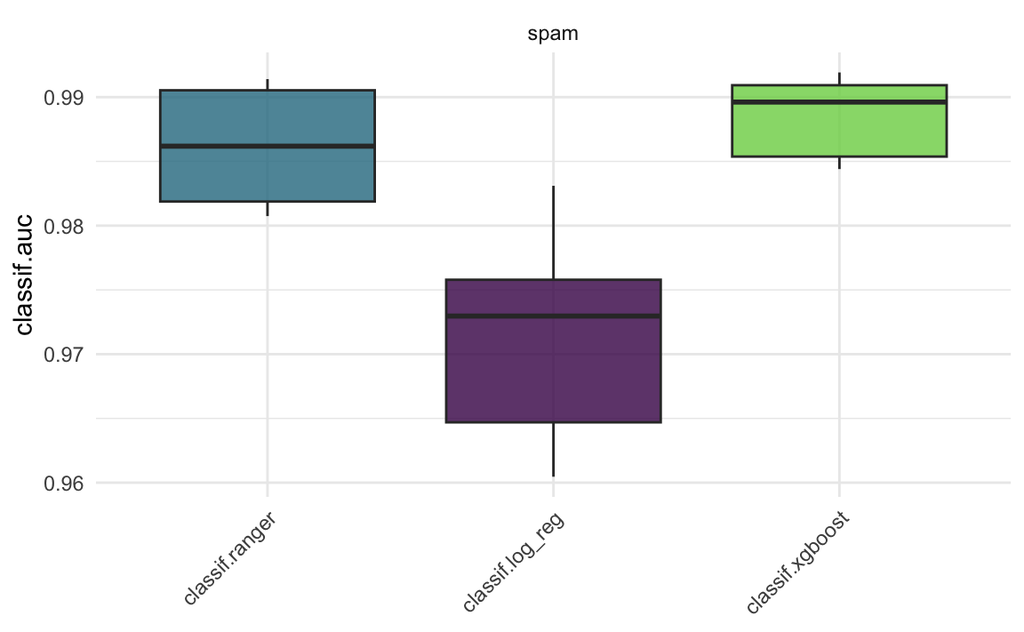

```r
autoplot(bmr, measure = msr("classif.auc"))
```

So, from a naive look at this, it appears that the XGBoost model performs the best (highest AUC). However, the results from all three of these models appear very similar, and I would maybe prefer “simplier” models over more flexible ones in this case (here, the logistic regression model).

If we run this 5 times with different seeds, let’s see how the AUC varies.

```r
bmr_auc <- rbindlist(lapply(seq_len(5), function(i) {
                         tmp_seed <- i * 100
                         set.seed(tmp_seed)
                         design <- benchmark_grid(tsk_spam, learners, cv5)
                         bmr <- benchmark(design)
                         data.table(
                                       seed = tmp_seed,
                                       auc = bmr$aggregate(msr("classif.auc"))
                                       )
                    })
                )


bmr_auc[, .(seed, auc.learner_id, auc.classif.auc)]
```

```
     seed  auc.learner_id auc.classif.auc
    <num>          <char>           <num>
 1:   100  classif.ranger       0.9866242
 2:   100 classif.log_reg       0.9708618
 3:   100 classif.xgboost       0.9883961
 4:   200  classif.ranger       0.9864776
 5:   200 classif.log_reg       0.9705954
 6:   200 classif.xgboost       0.9879994
 7:   300  classif.ranger       0.9855379
 8:   300 classif.log_reg       0.9710461
 9:   300 classif.xgboost       0.9878387
10:   400  classif.ranger       0.9866107
11:   400 classif.log_reg       0.9697749
12:   400 classif.xgboost       0.9888800
13:   500  classif.ranger       0.9862768
14:   500 classif.log_reg       0.9702488
15:   500 classif.xgboost       0.9879613
```

```r
# some summary stats
bmr_auc[, as.list(summary(auc.classif.auc)), by = auc.learner_id]
```

```
    auc.learner_id      Min.   1st Qu.    Median      Mean   3rd Qu.      Max.
            <char>     <num>     <num>     <num>     <num>     <num>     <num>
1:  classif.ranger 0.9855379 0.9862768 0.9864776 0.9863055 0.9866107 0.9866242
2: classif.log_reg 0.9697749 0.9702488 0.9705954 0.9705054 0.9708618 0.9710461
3: classif.xgboost 0.9878387 0.9879613 0.9879994 0.9882151 0.9883961 0.9888800
```

From this, it does appear that the logistic regression model is consistently worse, but there is not much difference in the other two models (although XGBoost always very slighly outperforms the random forest model, after aggregation). The choice of model will depend on how important that small difference is in the AUC compared to model complexity.

## Question 3

A colleague reports a $93.1\%$ classification accuracy using `lrn("classif.rpart")` on `tsk("penguins_simple")`.

- You want to reproduce their results and ask them about their resampling strategy.
- They said they used a custom three-fold CV with folds assigned as `factor(task$row_ids %% 3)`.
- See if you can reproduce their results.

### Answer

Let’s have a look at the `Task`. This task doesn’t seem to be in included in the default {mlr3} package, but is referenced in the {mlr3data} (Becker 2024) [docs](https://mlr3data.mlr-org.com/reference/penguins_simple.html).

Becker, Marc. 2024. *Mlr3data: Collection of Machine Learning Data Sets for ’Mlr3’*. https://github.com/mlr-org/mlr3data.

```r
tsk_penguins <- tsk("penguins_simple")
tsk_penguins
```

```
<TaskClassif:penguins> (333 x 11): Simplified Palmer Penguins
* Target: species
* Properties: multiclass
* Features (10):
  - dbl (7): bill_depth, bill_length, island.Biscoe, island.Dream,
    island.Torgersen, sex.female, sex.male
  - int (3): body_mass, flipper_length, year
```

OK, so this is a multi-class classification task, using 10 features to predict the species of the penguin.

They said they used a custom three-folds CV, so let’s try and reproduce this. By looking at `factor(tsk_penguins$row_ids %% 3)`, we can see that the CV is putting every third observation into the same fold. This feels weird and wrong, but whatever.

```r
# load learner
lrn_rpart <- lrn("classif.rpart")
lrn_rpart
```

```
<LearnerClassifRpart:classif.rpart>: Classification Tree
* Model: -
* Parameters: xval=0
* Packages: mlr3, rpart
* Predict Types:  [response], prob
* Feature Types: logical, integer, numeric, factor, ordered
* Properties: importance, missings, multiclass, selected_features,
  twoclass, weights
```

```r
# create custom resampling strategy
rsmp_custom = rsmp("custom_cv")
folds <- factor(tsk_penguins$row_ids %% 3)
rsmp_custom$instantiate(tsk_penguins, f = folds)
rr <- resample(tsk_penguins, lrn_rpart, rsmp_custom)
rr$predictions()
```

```
[[1]]
<PredictionClassif> for 111 observations:
 row_ids     truth  response
       3    Adelie    Adelie
       6    Adelie    Adelie
       9    Adelie    Adelie
     ---       ---       ---
     327 Chinstrap Chinstrap
     330 Chinstrap    Adelie
     333 Chinstrap Chinstrap

[[2]]
<PredictionClassif> for 111 observations:
 row_ids     truth  response
       1    Adelie    Adelie
       4    Adelie    Adelie
       7    Adelie    Adelie
     ---       ---       ---
     325 Chinstrap Chinstrap
     328 Chinstrap Chinstrap
     331 Chinstrap Chinstrap

[[3]]
<PredictionClassif> for 111 observations:
 row_ids     truth response
       2    Adelie   Adelie
       5    Adelie   Adelie
       8    Adelie   Adelie
     ---       ---      ---
     326 Chinstrap   Gentoo
     329 Chinstrap   Gentoo
     332 Chinstrap   Gentoo
```

```r
rr$score(msr("classif.acc"))
```

```
    task_id    learner_id resampling_id iteration classif.acc
     <char>        <char>        <char>     <int>       <num>
1: penguins classif.rpart     custom_cv         1   0.9369369
2: penguins classif.rpart     custom_cv         2   0.9189189
3: penguins classif.rpart     custom_cv         3   0.9369369
Hidden columns: task, learner, resampling, prediction_test
```

```r
rr$aggregate(msr("classif.acc"))
```

```
classif.acc
  0.9309309
```

So, we get a model with $93.1\%$ accuracy, as required.

## Question 4

(*) Program your own ROC plotting function **without** using `mlr3`’s `autoplot()` function.

- The signature of your function should be `my_roc_plot(task, learner, train_indices, test_indices)`.
- Your function should use the `$set_threshold()` method of `Prediction`, as well as `mlr3measures`.

### Answer

Let’s first have a look at the output from using `autoplot()`. I’ll use the `german_credit` task.

```r
tsk_german = tsk("german_credit")
tsk_german
```

```
<TaskClassif:german_credit> (1000 x 21): German Credit
* Target: credit_risk
* Properties: twoclass
* Features (20):
  - fct (14): credit_history, employment_duration, foreign_worker,
    housing, job, other_debtors, other_installment_plans,
    people_liable, personal_status_sex, property, purpose, savings,
    status, telephone
  - int (3): age, amount, duration
  - ord (3): installment_rate, number_credits, present_residence
```

```r
lrn_ranger = lrn("classif.ranger", predict_type = "prob")
splits = partition(tsk_german, ratio = 0.8)

lrn_ranger$train(tsk_german, splits$train)
prediction = lrn_ranger$predict(tsk_german, splits$test)
```

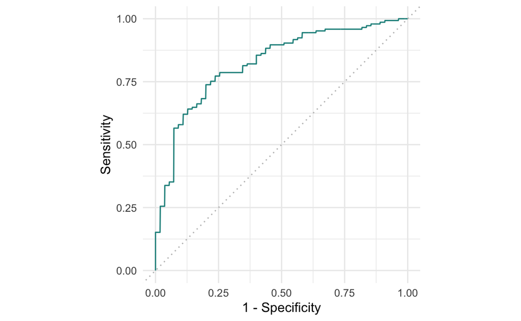

```r
autoplot(prediction, type = "roc")
```

First, I’ll do all the steps to create the ROC, then I’ll wrap this in a function, `my_roc_plot()`.

#### Creating the ROC

OK – so I need to use [`$set_threshold()`](https://mlr3.mlr-org.com/reference/PredictionClassif.html#method-PredictionClassif-set_threshold) to obtain predictions over the range of thresholds. Then, I need to use {mlr3measures} (Lang, Becker, and Koers 2024) to compute the TPR (Sensitivity) and FPR (1 - Specificity) and plot these all on a lovely graph.

Lang, Michel, Marc Becker, and Lona Koers. 2024. *Mlr3measures: Performance Measures for ’Mlr3’*. https://CRAN.R-project.org/package=mlr3measures.

I’ll first check to see which is the `positive` outcome in the `Task`.

```r
tsk_german$positive
```

```
[1] "good"
```

```r
# also, by looking at the help file 'prediction$help()'
# can see that the positive class is the first level of '$truth', i.e.
levels(prediction$truth)[1]
```

```
[1] "good"
```

So having `good` credit is the positive outcome here.

Now, I’ll create a vector of thresholds[^6] and then obtain predictions and calculate the measures.

<sup>6</sup> Thresholds were discussed in [Section 2.5.4](https://mlr3book.mlr-org.com/chapters/chapter2/data_and_basic_modeling.html#sec-classif-prediction) of the mlr3 tutorial.

```r
positive_class <- levels(prediction$truth)[1]
thresholds <- seq(0, 1, length = 101)
tsk_german_measures <- rbindlist(
         lapply(thresholds, function(j) {
                prediction$set_threshold(j)
                tpr_tmp <- mlr3measures::tpr(truth = prediction$truth,
                                             response = prediction$response,
                                             positive = positive_class)
                fpr_tmp <- mlr3measures::fpr(truth = prediction$truth,
                                             response = prediction$response,
                                             positive = positive_class)
                data.table(threshold = j,
                           tpr = tpr_tmp,
                           fpr = fpr_tmp)
                    }
                 )
         )

# order by increasing fpr, and tpr
# s.t. the step function avoids spikes
# spikes are happening as seed not set in $set_threshold(),
# so possible to get non-monotonic tpr/ fpr
tsk_german_measures <- tsk_german_measures[order(fpr, tpr)]
tsk_german_measures
```

```
     threshold         tpr   fpr
         <num>       <num> <num>
  1:      0.99 0.000000000     0
  2:      1.00 0.000000000     0
  3:      0.98 0.006896552     0
  4:      0.96 0.013793103     0
  5:      0.97 0.013793103     0
 ---
 97:      0.22 1.000000000     1
 98:      0.23 1.000000000     1
 99:      0.24 1.000000000     1
100:      0.25 1.000000000     1
101:      0.26 1.000000000     1
```

OK, I think I’ve got everything required to plot the ROC.

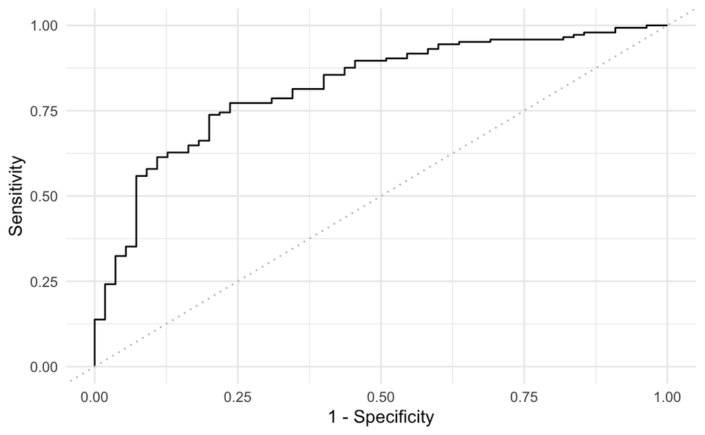

```r
ggplot(tsk_german_measures, aes(x = fpr, y = tpr)) +
        geom_step() +
        geom_abline(intercept = 0, slope = 1,
                    linetype = "dotted", colour = "grey") +
        labs(x = "1 - Specificity",
             y = "Sensitivity") +
        theme_minimal()
```

#### Making the function `my_roc_plot()`

```r
my_roc_plot <- function(task, learner, train_indices, test_indices) {
        # task: a 'Task' object
        # learner: a 'Learner' object

        # train the learner on the task
        learner$train(task, row_ids = train_indices)
        # create the prediction object
        prediction <- learner$predict(task, row_ids = test_indices)

        # find TPR and FPR over a seq of thresholds
        positive_class <- levels(prediction$truth)[1]
        thresholds <- seq(0, 1, length = 101)
        tpr_fpr_thresholds <- rbindlist(
                 lapply(thresholds, function(j) {
                        prediction$set_threshold(j)
                        tpr_tmp <- mlr3measures::tpr(truth = prediction$truth,
                                                     response = prediction$response,
                                                     positive = positive_class)
                        fpr_tmp <- mlr3measures::fpr(truth = prediction$truth,
                                                     response = prediction$response,
                                                     positive = positive_class)
                        data.table(threshold = j,
                                   tpr = tpr_tmp,
                                   fpr = fpr_tmp)
                            }
                         )
                 )

        tpr_fpr_thresholds <- tpr_fpr_thresholds[order(fpr, tpr)]

        # and plot
        ggplot(tpr_fpr_thresholds, aes(x = fpr, y = tpr)) +
                geom_step() +
                geom_abline(intercept = 0, slope = 1,
                            linetype = "dotted", colour = "grey") +
                labs(x = "1 - Specificity",
                     y = "Sensitivity") +
                theme_minimal()

}
```

Let’s test it:

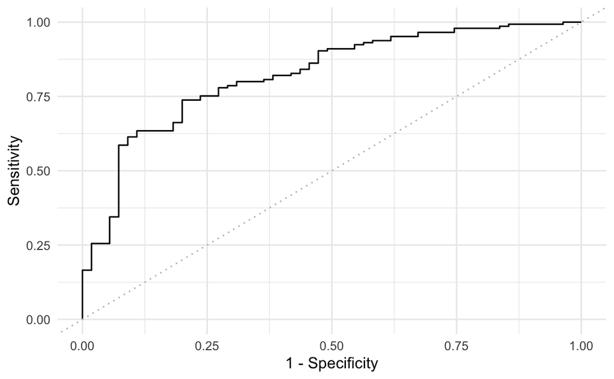

```r
my_roc_plot(task = tsk_german,
            learner = lrn("classif.ranger", predict_type = "prob"),
            train_indices = splits$train,
            test_indices = splits$test)
```

Cool, looks good!